# Insights and Data Visualisation Report:

### WeRateDogs Twitter Data

The dataset that I have used for this project data analysis and visualization is the tweet archive of Twitter user @dog_rates, also known as WeRateDogs.WeRateDogs is a Twitter account that rates people's dogs with a humorous comment about the dog. These ratings almost always have a denominator of 10. The numerators, though? Almost always greater than 10. 11/10, 12/10, 13/10, etc. Why? Because "they're good dogs Brent." WeRateDogs has over 4 million followers and has received international media coverage.

#### Objective of Report:

In this project report we are going to show results of our data wrangling activity in the form of Analysis and visualisation. Reporting on : -Data analysis and visualizations.

# Data Visualisation for Most Rated Dogs:

Before I begin analysis the data had to be wrangled into a cleaned dataset shape to make it easier to analyse.Data was both analysed programatically and visually.The quality of data is determined by looking at several aspects and dimensions of data like Completeness,Validity,Accuracy and consistency.

In this part of data anlysis we looked for most rated dogs in our master clean dataset and analysed through histogram that what is the most popular type of dog.

### Histogram Representation:

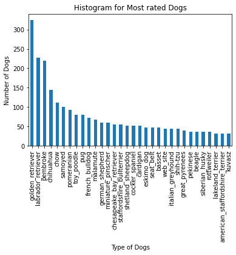

# Data Visualisation on 'DOGTIONARY'(various stages of Dogs)

In this case stages of dogs was analysed from master dataset to further investigate about tweets and popularity of dogs.we used Pie chart representation to see which stage of dog has more popularity in terms of tweets.so following is the pictorial representation of this data analysis part.

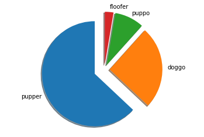

### Analysis:

Dogs in Pupper stage of dog life cycle get most tweets, which is expected.

# Scatter plot between favorites and retweets.

This analysis Analysis: We have to analyse corelation between number of retweets and favorite tweets.

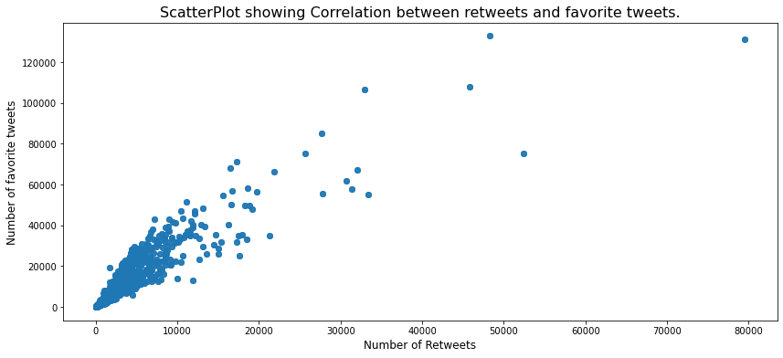

### Analysis:

As we can see there is a correlation between the number of retweets and the favorites for every tweet which shows how humans could react more positively and make them favorite tweets, for the tweets or posts that they likes better .

The above plot shows there is a positive corelation between number of retweets and favorite tweets.Basically we can interpret a scatterplot by looking for trends in the data as we go from left to right: If the data show an uphill pattern as we move from left to right, this indicates a positive relationship between X and Y. As the X-values increase (move right), the Y-values tend to increase (move up)